# NCICS Machine Learning Tutorial - E05

Welcome to Lecture 5 of the North Carolina Institute for Climate Studies’ Machine Learning Course. This session will be our first hands-on lesson in data wrangling and simple machine learning.

## Introduction

### Session contents

In this session, we will be covering the following topics:

1. Data preprocessing basics;
2. K-nearest neighbors classifiers;
3. Cross-validation;
4. Impact of hyperparameters on model;

### About the data set

The data set is actual satellite imagery of our home city of Asheville, taken from Landsat 8, an imaging satellite that was launched in 2013.

Check out the following links for more information: https://www.usgs.gov/land-resources/nli/landsat/landsat-8?qt-science_support_page_related_con=0#qt-science_support_page_related_con

https://landsat.gsfc.nasa.gov/landsat-data-continuity-mission/

## Data preprocessing basics

Before we starts to read in the data and create our first classifier, we need to load libraries that will be used in the notebook. We will heavily rely on [**caret**](https://topepo.github.io/caret/index.html) library in R for model training. *caret* is a powerful wrapper package which calls hunders of machine learning packages in R and simplify model training and application process.

```r
library(caret); library(e1071)                                    # pacakge for ML model training
library(ggplot2); library(cowplot)                                # package for visualization
library(readr); library(dplyr)                                    # package for data handeling
```

### Step 1 - Data ingest

First thing first, we will read in the data for this notebook which is included in this Github repository. The data file [*NC_L8_GroundTruth.csv*](https://github.com/geo-yrao/ML4ES-tutorials/blob/master/NC_L8_GroundTruth.csv) contains sampled pixels in western North Carolina. The data contains both the multispectral reflectance from Landsat-8 OLI data and corresponding land cover types from USGS Cropland Data Layer (CDL).

```r
## Here, we read in the data pairs between reflectance (scale factor: 0.0001) and land cover types
fname <- "~/MLtraining/noaa-ai-ml-distribution-raju/lulc-ashville/NC_L8_GroundTruth.csv"
AVLData <- read_csv(fname)
```

### Step 2 - View data

Our data contains the location (*“Latitude”,“Longitude”*), land cover type (*“Class”*), and reflectance of six OLI channels (*“B1”~“B6”*). Let’s first check how the data frame looks like.

```r
## We can show the first 10 rows of the data frame
head(AVLData, 10)
```

| X1 | Latitude | Longitude | Class | B1 | B2 | B3 | B4 | B5 | B6 |
| --- | --- | --- | --- | --- | --- | --- | --- | --- | --- |
| 1 | 35.51477 | -82.68045 | 0 | 127 | 150 | 550 | 226 | 3609 | 1441 |
| 2 | 35.75398 | -82.52043 | 0 | 81 | 115 | 426 | 170 | 2913 | 1110 |
| 3 | 35.71063 | -82.30566 | 0 | 156 | 220 | 538 | 477 | 2492 | 2077 |
| 4 | 35.51281 | -82.41386 | 0 | 245 | 280 | 663 | 507 | 2732 | 1531 |
| 5 | 35.52064 | -82.85318 | 0 | 148 | 181 | 534 | 265 | 3320 | 1457 |
| 6 | 35.61906 | -82.80788 | 0 | 202 | 289 | 651 | 522 | 3047 | 2251 |
| 7 | 35.55420 | -82.50479 | 0 | 208 | 250 | 521 | 408 | 2905 | 1738 |
| 8 | 35.56040 | -82.30077 | 0 | 60 | 91 | 486 | 184 | 3431 | 1342 |
| 9 | 35.54573 | -82.50511 | 0 | 122 | 155 | 463 | 219 | 3385 | 1264 |
| 10 | 35.64937 | -82.47969 | 0 | 207 | 260 | 603 | 441 | 3205 | 1801 |

The following table present the information about the six [OLI chanles](https://en.wikipedia.org/wiki/Landsat_8) included in the data. The reflectance data can provide unique information to charaterize different land cover types.

| Channel No. | Channel Name | Wavelength |
| --- | --- | --- |
| B1 | Coastal/Areasol | 0.433 – 0.453 μm |
| B2 | Blue | 0.450 – 0.515 μm |
| B3 | Green | 0.525 – 0.600 μm |
| B4 | Red | 0.630 – 0.680 μm |
| B5 | Near Infrared | 0.845 – 0.885 μm |
| B6 | Short Wavelength Infrared | 1.560 – 1.660 μm |

### Step 3 - Viewing class historgram

We want to understand how many samples belong to each land cover types. In our data, there are five different land cover types as listed in the table below.

| Class No. | Land Cover Type |
| --- | --- |
| 0 | Forest |
| 1 | Corn |
| 2 | Soy |
| 3 | Development/Urban |
| 4 | Water |

Here, we create a histogram to examing the histogram of land cover types in the data.

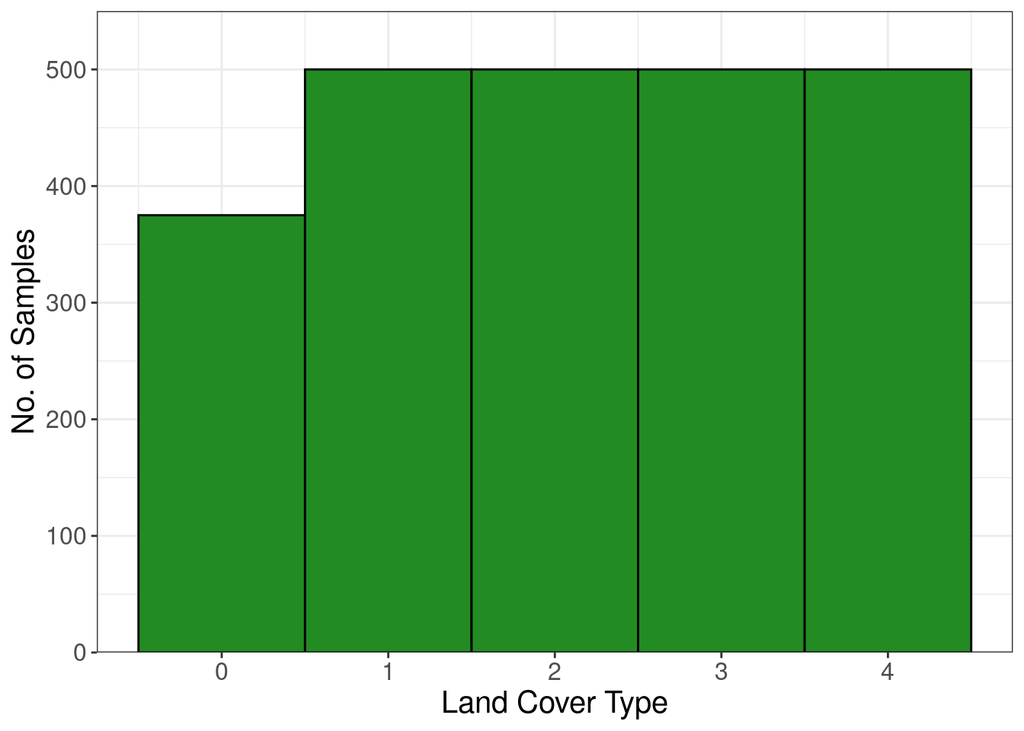

```r
# Show the histogram of different land cover types using ggplot2
AVLData %>% ggplot() + geom_histogram(aes(Class), binwidth = 1, color="black", fill="forestgreen") +
  labs(x="Land Cover Type", y="No. of Samples") + coord_cartesian(ylim=c(0,550), xlim=c(-0.75,4.75), expand=F) +
  theme_bw() + theme(text=element_text(size=15))
```

As you can see, the data is overall well balanced across different land cover types except for forest (*Class == 0*).

### Step 4 - Simpilying to a binary example

As our first classifier, let’s focus on a binary classifier example. So we only keep samples of forests (*Class == 0*) and water (*Class == 4*).

```r
## We use filter function from dplyr to screen the data
binData <- AVLData %>% filter(Class == 0 | Class == 4); str(binData);
```

```
## Classes 'spec_tbl_df', 'tbl_df', 'tbl' and 'data.frame': 875 obs. of  10 variables:
##  $ X1       : num  1 2 3 4 5 6 7 8 9 10 ...
##  $ Latitude : num  35.5 35.8 35.7 35.5 35.5 ...
##  $ Longitude: num  -82.7 -82.5 -82.3 -82.4 -82.9 ...
##  $ Class    : num  0 0 0 0 0 0 0 0 0 0 ...
##  $ B1       : num  127 81 156 245 148 202 208 60 122 207 ...
##  $ B2       : num  150 115 220 280 181 289 250 91 155 260 ...
##  $ B3       : num  550 426 538 663 534 651 521 486 463 603 ...
##  $ B4       : num  226 170 477 507 265 522 408 184 219 441 ...
##  $ B5       : num  3609 2913 2492 2732 3320 ...
##  $ B6       : num  1441 1110 2077 1531 1457 ...
##  - attr(*, "spec")=
##   .. cols(
##   ..   X1 = col_double(),
##   ..   Latitude = col_double(),
##   ..   Longitude = col_double(),
##   ..   Class = col_double(),
##   ..   B1 = col_double(),
##   ..   B2 = col_double(),
##   ..   B3 = col_double(),
##   ..   B4 = col_double(),
##   ..   B5 = col_double(),
##   ..   B6 = col_double()
##   .. )
```

```r
## To facilitate the classifier development, we convert the data type of Class from integer to factor in R
binData$Class <- factor(binData$Class, levels = c(0,4), labels = c("Forest", "Water"))
```

As we can see, there are only **875** samples for our binary case instead of all **2375** samples.

### Step 5 - Visualize data in the feature space

With the binary class example, we can examine the features (i.e., reflectance) that will be used for building the classifier. We use Channel 4 and 6 as an example. Please consider modify the code below to explore different feature combination.

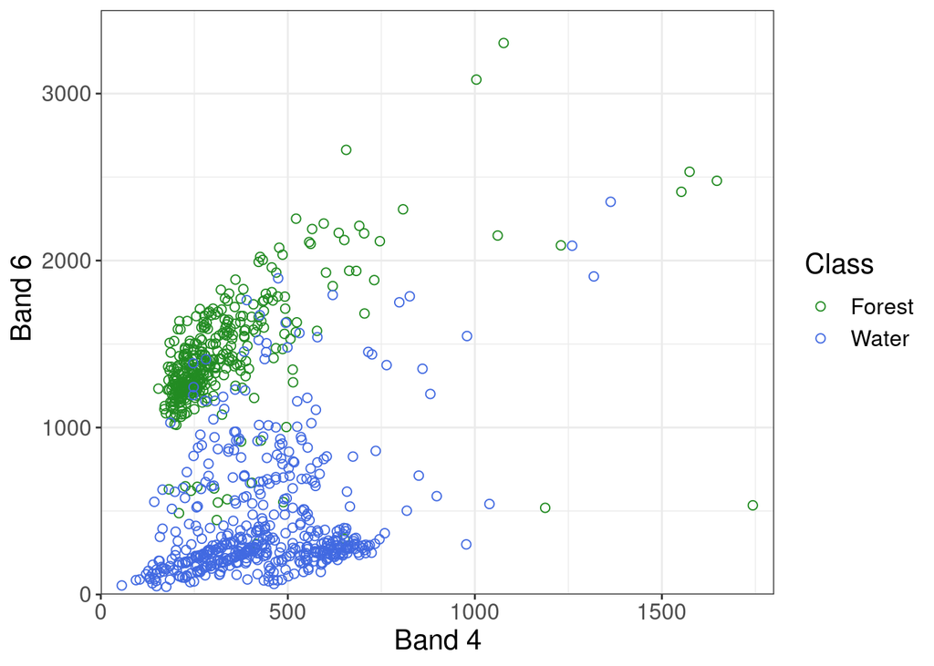

```r
## We use ggplot2 again here to plot the scatter plot of B4 and B6
binData %>% ggplot(aes(x=B4,y=B6)) + geom_point(aes(color=Class), pch=21, size=2) + theme_bw() +
  coord_cartesian(xlim=c(0, 1800), ylim=c(0, 3500), expand=F) +
  scale_color_manual(values = c("forestgreen", "royalblue")) + labs(x = "Band 4", y = " Band 6") +
  theme(text=element_text(size=15))
```

### Step 6 - Data splitting

To build our first machine learning model, we first need to **split the data** into different sets for model development and evaluation (i.e., model development and testing). Let’s follow the convention ratio of data seperation – 80% model development and 20% testing. We will implement cross validation in the training using the model development dataset.

There are different ways to implement data splitting. In our case, we want to make sure that both classes are well represented in both data sets. Idealy, we want our data set can reflect on the “reality” so we will use stratified spliting.

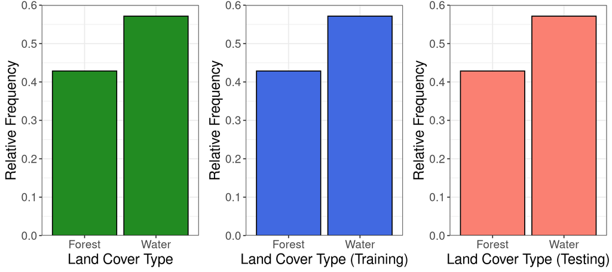

```r
## spliting the data based on the outcome -- land cover type; 80% for modeling, 20% for testing.
set.seed(6302)
trainIndex <- createDataPartition(binData$Class, p=0.8, list=FALSE, times = 1)
trainData <- binData[trainIndex,]; testData <- binData[-trainIndex,]

## Compare the relative frequency for both dataset with the original data using ggplot2
p1 <- binData %>% ggplot() + geom_bar(aes(Class, y=..count../nrow(binData)), color="black", fill="forestgreen") +
  labs(x="Land Cover Type", y="Relative Frequency") + scale_y_continuous(lim=c(0,0.6), breaks = seq(0,0.6,0.1), expand=c(0,0)) +
  theme_bw() + theme(text=element_text(size=15)) ## ploting for overall data
p2 <- trainData %>% ggplot() + geom_bar(aes(Class, y=..count../nrow(trainData)), color="black", fill="royalblue") +
  labs(x="Land Cover Type (Training)", y="Relative Frequency") +
  scale_y_continuous(lim=c(0,0.6), breaks = seq(0,0.6,0.1), expand=c(0,0)) +
  theme_bw() + theme(text=element_text(size=15)) ## ploting for training data
p3 <- testData %>% ggplot() + geom_bar(aes(Class, y=..count../nrow(testData)), color="black", fill="salmon") +
  labs(x="Land Cover Type (Testing)", y="Relative Frequency") +
  scale_y_continuous(lim=c(0,0.6), breaks = seq(0,0.6,0.1), expand=c(0,0)) +
  theme_bw() + theme(text=element_text(size=15)) ## ploting for testing data

## putting three plots together via cowplot::plot_grid function
cowplot::plot_grid(p1,p2,p3, nrow=1, ncol=3)
```

How would this splitting different from simple random spliting? Let’s see the difference!

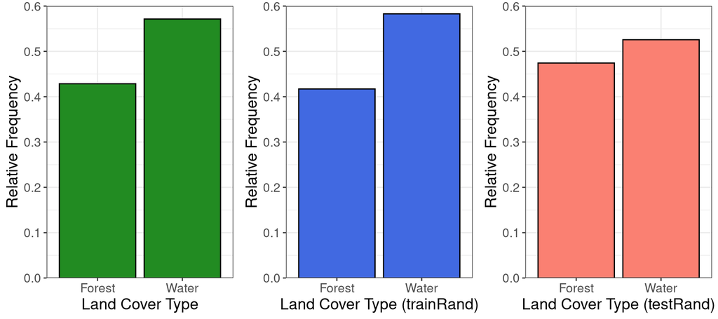

```r
set.seed(1001)
nobs <- nrow(binData)  # this get the total number of samples
randIndex <- sample(1:nobs, nobs*0.8); # First, we generate the random index for simple random sampling 80%:20%
trainRand <- binData[ randIndex,]; testRand <- binData[-randIndex,] ## simple random spliting dataset

## let's see the comparison of the relative frequency again
## Compare the relative frequency data for both dataset with the original data
p1 <- binData %>% ggplot() + geom_bar(aes(Class, y=..count../nrow(binData)), color="black", fill="forestgreen") +
  labs(x="Land Cover Type", y="Relative Frequency") + scale_y_continuous(lim=c(0,0.6), breaks = seq(0,0.6,0.1), expand=c(0,0)) +
  theme_bw() + theme(text=element_text(size=14)) ## ploting for overall data
p2 <- trainRand %>% ggplot() + geom_bar(aes(Class, y=..count../nrow(trainRand)), color="black", fill="royalblue") +
  labs(x="Land Cover Type (trainRand)", y="Relative Frequency") + scale_y_continuous(lim=c(0,0.6), breaks = seq(0,0.6,0.1), expand=c(0,0)) +
  theme_bw() + theme(text=element_text(size=14)) ## ploting for training data
p3 <- testRand %>% ggplot() + geom_bar(aes(Class, y=..count../nrow(testRand)), color="black", fill="salmon") +
  labs(x="Land Cover Type (testRand)", y="Relative Frequency") + scale_y_continuous(lim=c(0,0.6), breaks = seq(0,0.6,0.1), expand=c(0,0)) +
  theme_bw() + theme(text=element_text(size=14)) ## ploting for testing data

## putting three plots together via cowplot
cowplot::plot_grid(p1,p2,p3, nrow=1, ncol=3)
```

We can see the difference on the relative frequency in our dataset, which is something that we want to avoid when we are handling our dataset. In extreme cases, the imbalance sample could lead to unreliable model training and/or testing results.

## K-nearest neighbot

### Step 7 - K-nearest neighbor (k-NN)

Now we have training and testing data ready, let’s creat our first classifier, [**k-nearest neighbor (k-NN)**](https://en.wikipedia.org/wiki/K-nearest_neighbors_algorithm). There are different variations of k-NN model which are developed to improve its performance for different challenging tasks. But here we will use the classic k-NN model. In *caret* package, the k-NN model is represented using the tag *“knn”*. In R, you can simply get the model information using the function *getModelInfo* provided by *caret* package.

```r
## check how to use function getModelInfo
? getModelInfo
## check the specifics of the model k-NN. Since there are many different variations of k-nn, we want to match the model tag exactly by turning off the regular expression match.
getModelInfo(model="knn",regex=FALSE)
```

```
## $knn
## $knn$label
## [1] "k-Nearest Neighbors"
##
## $knn$library
## NULL
##
## $knn$loop
## NULL
##
## $knn$type
## [1] "Classification" "Regression"
##
## $knn$parameters
##   parameter   class      label
## 1         k numeric #Neighbors
##
## $knn$grid
## function(x, y, len = NULL, search = "grid"){
##                     if(search == "grid") {
##                       out <- data.frame(k = (5:((2 * len)+4))[(5:((2 * len)+4))%%2 > 0])
##                     } else {
##                       by_val <- if(is.factor(y)) length(levels(y)) else 1
##                       out <- data.frame(k = sample(seq(1, floor(nrow(x)/3), by = by_val), size = len, replace = TRUE))
##                     }
##                     out
##                   }
##
## $knn$fit
## function(x, y, wts, param, lev, last, classProbs, ...) {
##                     if(is.factor(y))
##                     {
##                       knn3(as.matrix(x), y, k = param$k, ...)
##                     } else {
##                       knnreg(as.matrix(x), y, k = param$k, ...)
##                     }
##                   }
##
## $knn$predict
## function(modelFit, newdata, submodels = NULL) {
```

[output cut: 9 more lines]

```
## $knn$predictors
## function(x, ...) colnames(x$learn$X)
##
## $knn$tags
## [1] "Prototype Models"
##
## $knn$prob
## function(modelFit, newdata, submodels = NULL)
##                     predict(modelFit, newdata, type = "prob")
##
## $knn$levels
## function(x) levels(x$learn$y)
##
## $knn$sort
## function(x) x[order(-x[,1]),]
```

This model information tells us that there is only one model hyperparameter need to be specified to train a k-NN model. To start with the model, we will simply use **k=10** for our first k-NN model without any cross-validation. In *caret*, the function **trainControl** compiles the model training process.

```r
set.seed(998)
## To start our model, we will fix k = 10 without cross validation

## trainControl function in R sepecifies whether and how to train your model
LogControl <- trainControl(method = "none", classProbs = TRUE)

## using train function to train the model
knnClassifier <- train(Class ~ B1 + B2 + B3 + B4 + B5 + B6, data = trainData, method = "knn",
                 trControl = LogControl, tuneGrid = data.frame(k=10))

knnClassifier
```

```
## k-Nearest Neighbors
##
## 700 samples
##   6 predictor
##   2 classes: 'Forest', 'Water'
##
## No pre-processing
## Resampling: None
```

### Step 8 - Generate confusion matrix

Just like that, we have our first k-NN classifier. How did our model do? We can find out using the confusion matrix.

```r
## First, we can extract the predicted class of our k-nn (k=10) model
predClass <- predict(knnClassifier)
## Now, we can combine the predicted class and true class in the trainData to construct our confusion matrix
cfMatrix <- confusionMatrix(predClass, trainData$Class)
cfMatrix
```

```
## Confusion Matrix and Statistics
##
##           Reference
## Prediction Forest Water
##     Forest    286    18
##     Water      14   382
##
##                Accuracy : 0.9543
##                  95% CI : (0.9361, 0.9685)
##     No Information Rate : 0.5714
##     P-Value [Acc > NIR] : <2e-16
##
##                   Kappa : 0.9068
##
##  Mcnemar's Test P-Value : 0.5959
##
##             Sensitivity : 0.9533
##             Specificity : 0.9550
##          Pos Pred Value : 0.9408
##          Neg Pred Value : 0.9646
##              Prevalence : 0.4286
##          Detection Rate : 0.4086
##    Detection Prevalence : 0.4343
##       Balanced Accuracy : 0.9542
##
##        'Positive' Class : Forest
##
```

### Step 9 - Evaluate model using testing data

From the confusion matrix, it looks like that our first k-NN model did a decent job on separating these two classes with an accuracy of 0.9543. But how would this model perform on the independent testing data that we set aside at the begining?

```r
## Applying our k-NN model to our testData & generate confusion matrix for testing data
knnTest <- predict(knnClassifier, newdata = testData)
cfMatrixTest <- confusionMatrix(knnTest, testData$Class)
cfMatrixTest
```

```
## Confusion Matrix and Statistics
##
##           Reference
## Prediction Forest Water
##     Forest     72    10
##     Water       3    90
##
##                Accuracy : 0.9257
##                  95% CI : (0.8763, 0.9599)
##     No Information Rate : 0.5714
##     P-Value [Acc > NIR] : < 2e-16
##
##                   Kappa : 0.8501
##
##  Mcnemar's Test P-Value : 0.09609
##
##             Sensitivity : 0.9600
##             Specificity : 0.9000
##          Pos Pred Value : 0.8780
##          Neg Pred Value : 0.9677
##              Prevalence : 0.4286
##          Detection Rate : 0.4114
##    Detection Prevalence : 0.4686
##       Balanced Accuracy : 0.9300
##
##        'Positive' Class : Forest
##
```

## Cross validation

### Step 10 - Cross-validation & Grid Search

```r
## here, we modify the trainControl function to use 5-fold cross-validation
cvControl <- trainControl(method="cv", number = 5)

## we also need to specify the grid we want the hyperparameter tuning to search
cvGrid <- data.frame(k = seq(1,15,1)); str(cvGrid)
```

```
## 'data.frame':    15 obs. of  1 variable:
##  $ k: num  1 2 3 4 5 6 7 8 9 10 ...
```

```r
set.seed(982)
## Now, we can implement the cross-validation using train function
knnCV <- train(Class ~ B1 + B2 + B3 + B4 + B5 + B6, data = trainData, method = "knn",
               trControl = cvControl, tuneGrid = cvGrid)

## Here is how our the cross-validation output looks like
knnCV
```

```
## k-Nearest Neighbors
##
## 700 samples
##   6 predictor
##   2 classes: 'Forest', 'Water'
##
## No pre-processing
## Resampling: Cross-Validated (5 fold)
## Summary of sample sizes: 560, 560, 560, 560, 560
## Resampling results across tuning parameters:
##
##   k   Accuracy   Kappa
##    1  0.9485714  0.8951904
##    2  0.9428571  0.8831818
##    3  0.9500000  0.8981500
##    4  0.9500000  0.8980774
##    5  0.9514286  0.9011088
##    6  0.9514286  0.9009889
##    7  0.9557143  0.9098666
##    8  0.9557143  0.9098541
##    9  0.9542857  0.9067385
##   10  0.9542857  0.9068227
##   11  0.9500000  0.8979816
##   12  0.9500000  0.8979945
##   13  0.9500000  0.8978856
##   14  0.9485714  0.8949267
##   15  0.9514286  0.9008449
##
## Accuracy was used to select the optimal model using the largest value.
## The final value used for the model was k = 8.
```

## Impact of hyperparameters on model performance

### Step 11 - Visualize CV results

Based on the cross-validation result, the *train* function decide to choose 8 as the optimum value for the k-nn because it yields the highest accuracy. But let’s visualize it using accuracy as the metric.

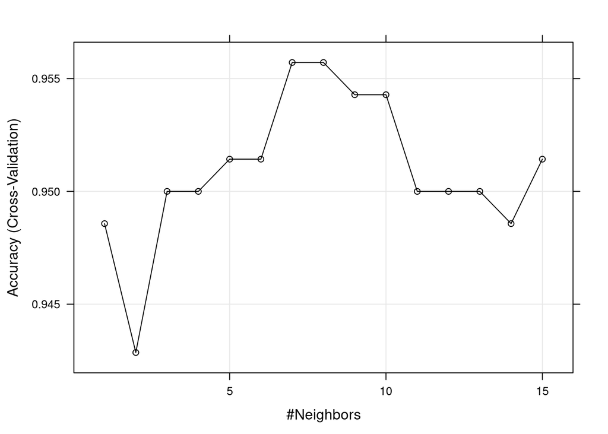

```r
## We can plot the accuracy as a function of different k values to assist our selection of the hyperparameter
trellis.par.set(caretTheme())  ## here, we set the them for the plot
plot(knnCV)
```

### Step 12 - Calculate final confusion matrix

We now calculates the confusion matrix as we have done before but for our model with optmized *k*.

```r
cvMatrix <- confusionMatrix(knnCV)
cvMatrix
```

```
## Cross-Validated (5 fold) Confusion Matrix
##
## (entries are percentual average cell counts across resamples)
##
##           Reference
## Prediction Forest Water
##     Forest   41.1   2.7
##     Water     1.7  54.4
##
##  Accuracy (average) : 0.9557
```

### Step 13 - Apply and evaluate the final model

Now we can apply this final model to our testing data to see if the optimized k value could improve the model performance.

```r
## apply the model to our testing data
testOutcome <- predict(knnCV, newdata = testData)

## generate the confusion matrix for the testing data
testMatrix <- confusionMatrix(testOutcome, testData$Class)
testMatrix
```

```
## Confusion Matrix and Statistics
##
##           Reference
## Prediction Forest Water
##     Forest     73    10
##     Water       2    90
##
##                Accuracy : 0.9314
##                  95% CI : (0.8833, 0.9641)
##     No Information Rate : 0.5714
##     P-Value [Acc > NIR] : < 2e-16
##
##                   Kappa : 0.8618
##
##  Mcnemar's Test P-Value : 0.04331
##
##             Sensitivity : 0.9733
##             Specificity : 0.9000
##          Pos Pred Value : 0.8795
##          Neg Pred Value : 0.9783
##              Prevalence : 0.4286
##          Detection Rate : 0.4171
##    Detection Prevalence : 0.4743
##       Balanced Accuracy : 0.9367
##
##        'Positive' Class : Forest
##
```

We could compare the confusion matrix with the one that we generated earlier for our first k-NN model with *k* fixed as 10.

```r
## This is our confusion matrix from the first k-NN model
cfMatrixTest
```

```
## Confusion Matrix and Statistics
##
##           Reference
## Prediction Forest Water
##     Forest     72    10
##     Water       3    90
##
##                Accuracy : 0.9257
##                  95% CI : (0.8763, 0.9599)
##     No Information Rate : 0.5714
##     P-Value [Acc > NIR] : < 2e-16
##
##                   Kappa : 0.8501
##
##  Mcnemar's Test P-Value : 0.09609
##
##             Sensitivity : 0.9600
##             Specificity : 0.9000
##          Pos Pred Value : 0.8780
##          Neg Pred Value : 0.9677
##              Prevalence : 0.4286
##          Detection Rate : 0.4114
##    Detection Prevalence : 0.4686
##       Balanced Accuracy : 0.9300
##
##        'Positive' Class : Forest
##
```

To conclude, the optimized k-NN model (k=8) via our cross-validation process yields better outcome than our first k-NN model when they were both evaluated using the independent testing data.